# Regresion lineal en R.

Dr. German Rosati

## Introducción

Ahora que tenemos claros algunos aspectos relevantes del preprocesamiento de datos con `tidyverse`, podemos empezar a pensar en un análisis un poco más elaborado. Para ello, vamos a usar nuestro viejo y conocido dataset de delitos pero lo vamos a combinar con información censal correspondiente a los radios de la CABA.

### Objetivos

- Introducir nociones generales de modelos lineales
- Presentar las funciones en R para estimar y evaluar dichos modelos

## Preprocesando el dataset

Vamos a combinar información de los radios censales con nuestro dataset de delitos. La pregunta general que vamos a abordar es ¿qué características tienen los radios censales en los que se cometen delitos en la CABA?

Primero, carguemos nuestro dataset de delitos, filtremos los datos sin información de latitud y longitud y demos el formato adecuado a las varaibles de fecha y hora.

```r
delitos <- read.csv('../data/delitos.csv')
delitos <- delitos %>%
        filter(latitud!=0 | longitud!=0) %>%
        mutate(fecha=ymd(fecha),
               hora=hms(hora))
```

Bien, ahora traigamos un datasets con información acerca de los radios censales de la ciudad.

```r
radios_gral <- st_read('../data/radios_info_gral.geojson')
str(radios_gral)
```

```
Classes ‘sf’ and 'data.frame':  3554 obs. of  28 variables:
 $ RADIO                   : Factor w/ 3554 levels "020010101","020010201",..: 1 139 148 149 140 141 142 143 144 145 ...
 $ RADIO_ID                : Factor w/ 3554 levels "1_1_1","1_10_1",..: 1 30 31 32 34 35 36 37 38 39 ...
 $ BARRIO                  : Factor w/ 48 levels "AGRONOMIA","ALMAGRO",..: 29 32 32 32 32 32 32 32 32 32 ...
 $ COMUNA                  : Factor w/ 15 levels "1","10","11",..: 1 1 1 1 1 1 1 1 1 1 ...
 $ POBLACION               : num  336 341 296 528 229 723 393 600 472 786 ...
 $ VIVIENDAS               : num  82 365 629 375 445 744 341 505 504 546 ...
 $ HOGARES                 : num  65 116 101 136 129 314 209 275 202 347 ...
 $ HOGARES_NBI             : num  19 25 1 7 16 104 110 32 49 89 ...
 $ AREA_KM2                : num  1.799 0.0186 0.0444 0.3663 0.0184 ...
 $ tasa_desoc              : num  3.64 5.71 1.36 2.08 4.99 ...
 $ tasa_act                : num  85.2 75.2 88.1 81.6 84.2 ...
 $ razon_masc              : num  1.71 1.174 1.208 1.257 0.789 ...
 $ prop_mayores            : num  0.00982 0.03871 0.03547 0.02254 0.04585 ...
 $ tasa_cal_construct_insuf: num  26.3 8.8 3.1 4.5 3.1 ...
```

[output cut: 20 more lines]

Ahora bien, este dataset es de un tipo particular. Si se fijan el último campo se llama geometry y contiene la información para plotear los politicos de los radios.

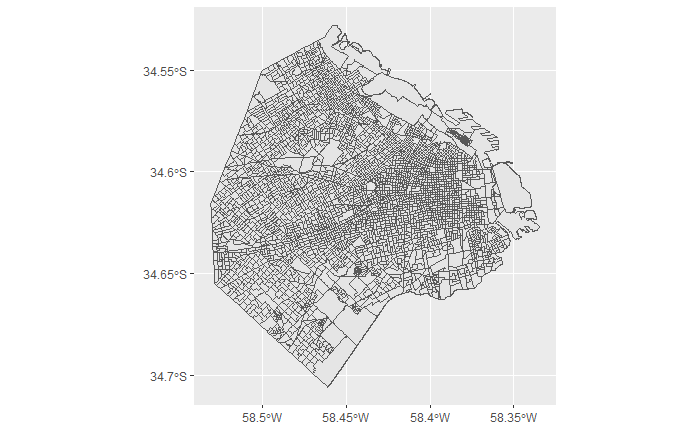

```r
ggplot() + geom_sf(data = radios_gral)
```

Para poder operar bien con los datasets conjuntos, tenemos que transformar los datos de delitos en un formato geográfico. Para ello usamos la librería [`sf`](https://cran.r-project.org/web/packages/sf/vignettes/sf1.html).

```r
delitos <- st_as_sf(delitos,
                    coords=c('longitud', 'latitud'),
                    crs=4326)
```

Básicamente, le pasamos a la función `st_as_sf` las columnas que contienen la información geográfica de coordenadas (`coords`) y la proyección (`crs`) en la que están los datos.

Ahora, vamos a hacer las cosas interesantes. La idea es poder realizar una operación que se llama “join espacial”. Vamos a tratar de contar cuántos delitos hubo en cada uno de los radios censales.

```r
ggplot() +
        geom_sf(data=radios_gral) +
        geom_sf(data=sample_n(delitos,1000), aes(color=tipo_delito)) +
        facet_wrap(~tipo_delito)
```

[output not shown]

La operación va a constar de dos partes: la primera, vemos a joinear los datos de delitos con los los de radio. Generamos una nuevo objeto llamado `delitos_radios` que contiene para cada delito, la información del tadio al que pertenece.

Usamos la función `st_join` que sirve par realizar estas operaciones. Pasamos ambos objetos como argumentos y usamos el argumento `st_within`.

```r
delitos_radio <- st_join(delitos,
                          radios_gral,
                          join = st_within) %>%
        as_tibble()
```

```
although coordinates are longitude/latitude, st_within assumes that they are planar
```

```r
head(delitos)
```

```
Simple feature collection with 6 features and 12 fields
geometry type:  POINT
dimension:      XY
bbox:           xmin: -58.5193 ymin: -34.6524 xmax: -58.4053 ymax: -34.5615
epsg (SRID):    4326
proj4string:    +proj=longlat +datum=WGS84 +no_defs
      id    comuna           barrio      fecha      hora
1  68400  Comuna 3        BALVANERA 2016-10-31  1H 0M 0S
2  68401  Comuna 7           FLORES 2016-10-31 2H 30M 0S
3  68402  Comuna 4    NUEVA POMPEYA 2016-10-31  4H 0M 0S
4  68492 Comuna 13         BELGRANO 2016-10-31 2H 58M 0S
5 132437  Comuna 9          LINIERS 2016-10-31 21H 0M 0S
6 132469 Comuna 11 VILLA SANTA RITA 2016-10-31  8H 0M 0S
         uso_arma uso_moto lugar origen_dato           tipo_delito
1 SIN USO DE ARMA SIN MOTO    NA          NA      Homicidio Doloso
2 SIN USO DE ARMA SIN MOTO    NA          NA      Homicidio Doloso
3 SIN USO DE ARMA SIN MOTO    NA          NA      Homicidio Doloso
4 SIN USO DE ARMA SIN MOTO    NA          NA    Homicidio Seg Vial
5 SIN USO DE ARMA SIN MOTO    NA          NA Hurto (Sin violencia)
6 SIN USO DE ARMA SIN MOTO    NA          NA Hurto (Sin violencia)
  cantidad_vehiculos cantidad_victimas                  geometry
1                  0                 0 POINT (-58.4117 -34.6141)
2                  0                 0 POINT (-58.4547 -34.6509)
3                  0                 0 POINT (-58.4053 -34.6499)
4                  0                 1 POINT (-58.4557 -34.5615)
5                  0                 0 POINT (-58.5193 -34.6524)
6                  0                 0 POINT (-58.4833 -34.6218)
```

Luego, contamos la cantidad de puntos en cada radio con un simple `group_by + summarise0` y realizamos un `left_join` con la tabla original de radios.

```r
radios_delitos <- delitos_radio %>%
        group_by(RADIO_ID) %>%
        summarise(n_delitos=n()) %>%
        left_join(x=radios_gral)
```

```
Factor `RADIO_ID` contains implicit NA, consider using `forcats::fct_explicit_na`Joining, by = "RADIO_ID"
```

Vemos, ahora, que el objeto `radios_delitos` es igual a `radios_general` pero con una columna más que se llama `n_delitos`

```r
str(radios_delitos)
```

```
Classes ‘sf’ and 'data.frame':  3554 obs. of  29 variables:
 $ RADIO                   : Factor w/ 3554 levels "020010101","020010201",..: 1 139 148 149 140 141 142 143 144 145 ...
 $ RADIO_ID                : Factor w/ 3554 levels "1_1_1","1_10_1",..: 1 30 31 32 34 35 36 37 38 39 ...
 $ BARRIO                  : Factor w/ 48 levels "AGRONOMIA","ALMAGRO",..: 29 32 32 32 32 32 32 32 32 32 ...
 $ COMUNA                  : Factor w/ 15 levels "1","10","11",..: 1 1 1 1 1 1 1 1 1 1 ...
 $ POBLACION               : num  336 341 296 528 229 723 393 600 472 786 ...
 $ VIVIENDAS               : num  82 365 629 375 445 744 341 505 504 546 ...
 $ HOGARES                 : num  65 116 101 136 129 314 209 275 202 347 ...
 $ HOGARES_NBI             : num  19 25 1 7 16 104 110 32 49 89 ...
 $ AREA_KM2                : num  1.799 0.0186 0.0444 0.3663 0.0184 ...
 $ tasa_desoc              : num  3.64 5.71 1.36 2.08 4.99 ...
 $ tasa_act                : num  85.2 75.2 88.1 81.6 84.2 ...
 $ razon_masc              : num  1.71 1.174 1.208 1.257 0.789 ...
 $ prop_mayores            : num  0.00982 0.03871 0.03547 0.02254 0.04585 ...
 $ tasa_cal_construct_insuf: num  26.3 8.8 3.1 4.5 3.1 ...
```

[output cut: 21 more lines]

Hagamos un primer mapa a ver qué pasa…

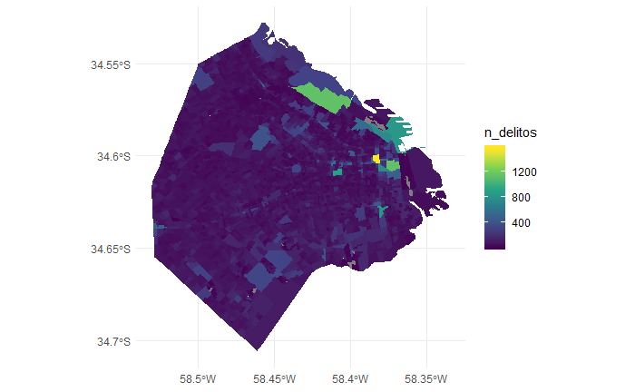

```r
ggplot() +
        geom_sf(data=radios_delitos,
                color=NA,
                aes(fill=n_delitos)) +
        scale_fill_viridis_c() +
        theme_minimal()
```

Ahora bien, pareciera que los radios con mayor cantidad de delitos son los que se encuentran en el centro de la ciudad o en zonas de alta población. Por ello, creemos una medida de “delitos / habitantes” para controlar este factor y aprovechemos para calcular una variable de densidad poblacional:

```r
radios_delitos <- radios_delitos %>%
        mutate(n_delitos_hab= n_delitos / POBLACION,
               dens_pob=POBLACION/AREA_KM2)
```

Y veamos ahora el plot…

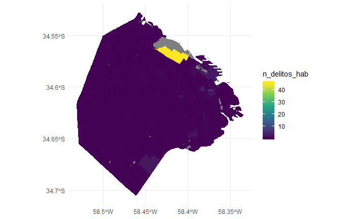

```r
ggplot() +
        geom_sf(data=radios_delitos,
                color=NA,
                aes(fill=n_delitos_hab)) +
        scale_fill_viridis_c() +
        theme_minimal()
```

Ahora la cosa parece bastante más homgénea… pero porque tenemos un caso muy raro. Vamos a truncar los valores a un máximo

```r
radios_delitos <- radios_delitos %>%
        mutate(n_delitos_hab = ifelse(n_delitos_hab >=0.6, 0.6, n_delitos_hab))
```

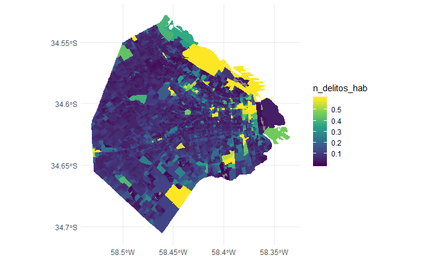

```r
radios_delitos %>%
ggplot() +
        geom_sf(
                color=NA,
                aes(fill=n_delitos_hab)) +
        scale_fill_viridis_c() +
        theme_minimal()
```

### Consigna

```r
radios_delitos <- delitos_radio %>%
        group_by(RADIO_ID, tipo_delito) %>%
        summarize(n=n()) %>%
        spread(key = tipo_delito, value = n) %>%
        left_join(x=radios_delitos) %>%
        replace(., is.na(.),0) %>%
        rename(hom_doloso='Homicidio Doloso',
               hom_segvial='Homicidio Seg Vial',
               robo_noviol='Hurto (Sin violencia)',
               hurto_auto = 'Hurto Automotor',
               les_segvial='Lesiones Seg Vial',
               robo_viol='Robo (Con violencia)',
               robo_auto='Robo Automotor'
               )
```

[output not shown]

Y ordenamos un poco el dataset…

```r
radios_delitos<- radios_delitos %>%
        mutate(homicidio = hom_doloso + hom_segvial,
               robo_automovil = hurto_auto + robo_auto) %>%
        select(-hom_doloso, -hom_segvial, -hurto_auto, -robo_auto)
```

- Generemos una variable con la proporción de Hogares NBI

```r
radios_delitos <- radios_delitos %>% mutate(p_hognbi = HOGARES_NBI/HOGARES *
    100) %>% replace_na(list(p_hognbi = 0))
```

## Introducción a la regresión lineal en R

Todos nos acordamos del modelo lineal:

$$Y_{i}=\beta_{0} + \beta_{1}*X_{i} + \epsilon_{i}$$

- Los parámetros del modelo son muy fáciles de interpretar:

$\beta_{0}$ es el intercepto

$\beta_{1}$ es la pendiente de la variable $X$; es decir el efecto medio en $Y$ cuando $X$ se incrementa en una unidad (y todo lo demás, se mantiene constante)

$\epsilon_{i}$ es el error o residuo de estimación

En un modelo lineal buscamos “minimizar” una determinada métrica de error. En particular, buscamos hacer mínimo el error cuadrático medio (MSE):

$$MSE=\frac{1}{n}\sum_{i=1}^{n}(Y_{i}-\hat{Y_{i}})^2$$

## Implementación en R `lm()`

Para implementar en R una regresión lineal simple usamos la función `lm()` * `formula`: una expresión con la siguiente forma: `y~x` * `data`: dataframe o datamatrix a utilizar * `subset`: un vector que define un subconjunto de datos a usar en el modelo * `weights`: vector que define pesos para la regresión (WLNS)

```r
model <- lm(formula = n_delitos ~ AREA_KM2, data = radios_delitos)
```

```r
summary(model)
```

```
Call:
lm(formula = n_delitos ~ AREA_KM2, data = radios_delitos)

Residuals:
    Min      1Q  Median      3Q     Max
-560.78  -31.18  -13.88    9.20 1490.21

Coefficients:
            Estimate Std. Error t value Pr(>|t|)
(Intercept)   57.798      1.319   43.83   <2e-16 ***
AREA_KM2     153.763      8.138   18.90   <2e-16 ***
---
Signif. codes:  0 ‘***’ 0.001 ‘**’ 0.01 ‘*’ 0.05 ‘.’ 0.1 ‘ ’ 1

Residual standard error: 73.52 on 3552 degrees of freedom
Multiple R-squared:  0.09134,   Adjusted R-squared:  0.09108
F-statistic:   357 on 1 and 3552 DF,  p-value: < 2.2e-16
```

Ahora tenemos acceso a mucha más información: * p-valores y errores estándar de los coeficientes. ¿Son significativos? * $R^2$: menos del 10% de la variancia de la variable dependiente es explicada por el modelo

Veamos qué hay dentro del objeto `model`. Usamos la función `names` para acceder a los objetos dentro del objeto `model`. Luego, podemos ir usando los nombres para acceder a los diferentes elementos.

```r
names(model)
```

```
 [1] "coefficients"  "residuals"     "effects"       "rank"
 [5] "fitted.values" "assign"        "qr"            "df.residual"
 [9] "xlevels"       "call"          "terms"         "model"
```

```r
model$coefficients
```

```
(Intercept)    AREA_KM2
   57.79752   153.76348
```

## Implementación en R `lm()`: Algunas funciones útiles:

Obtenemos intervalos de confianza de los parámetros del modelo.

```r
coef(model)
```

```
(Intercept)    AREA_KM2
   57.79752   153.76348
```

```r
confint(model, level = 0.95)
```

```
                2.5 %    97.5 %
(Intercept)  55.21212  60.38293
AREA_KM2    137.80871 169.71825
```

Veamos la función `predict()`

```r
predict(model, data.frame(AREA_KM2 = c(1, 10, 100), interval = "prediction"))
```

```
        1         2         3
  211.561  1595.432 15434.145
```

Es decir, que para si la variable independiente `AREA_KM2` presentara los valores 1, 10 y 100, la variable dependiente `n_delitos` presentaría esos valores (en la media).

Grafiquemos, ahora, todo.

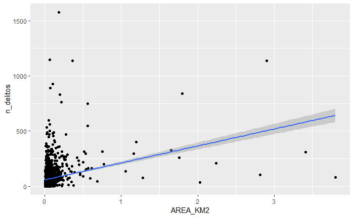

```r
ggplot(data = radios_delitos, aes(x = AREA_KM2, y = n_delitos)) + geom_point() +
    geom_smooth(method = "lm")
```

Generemos un modelo, ahora, que contenga todas las variables del dataset. Veamos, primero, la correlación entre varias variables:

```r
select(as.data.frame(radios_delitos), -c(RADIO:HOGARES_NBI, geometry)) %>% cor(method = "pearson")
```

```
                             AREA_KM2   tasa_desoc     tasa_act
AREA_KM2                  1.000000000  0.027929960 -0.123767578
tasa_desoc                0.027929960  1.000000000 -0.175775953
tasa_act                 -0.123767578 -0.175775953  1.000000000
razon_masc                0.276496395  0.036547152  0.141251592
prop_mayores              0.119987794 -0.209828293 -0.096635952
tasa_cal_construct_insuf  0.144959175  0.329082059  0.127115347
tasa_cal_serv_insuf       0.323568913  0.191255031  0.109181667
tasa_cal_mat_insuf        0.161713836  0.389195119 -0.008936087
dist_bancos               0.217646563  0.334244539 -0.158830649
dist_seguridad            0.142870189  0.144722554 -0.193536563
dist_tren                 0.020277722  0.151783598 -0.109821793
dist_subte                0.166485179  0.260388444 -0.378866108
dist_colectivo            0.219082565  0.202263563 -0.046518152
dist_metrobus             0.031158450  0.039352461 -0.071130985
n_dptos                   0.030821255 -0.273652426  0.250985597
mean_USS_M2              -0.044958753 -0.466959134  0.204149782
std_USS_M2               -0.008044273 -0.269962819  0.115672927
median_USS_M2            -0.039769360 -0.464856004  0.203458670
mad_USS2_M2              -0.037599804 -0.332538866  0.154194499
n_delitos                 0.302220317  0.009591662  0.045295303
n_delitos_hab             0.287940899 -0.004361832  0.069389914
dens_pob                 -0.260986962 -0.038171640  0.115627408
robo_noviol               0.170691470 -0.042288299  0.081846436
les_segvial               0.427982641  0.007297648 -0.022412288
robo_viol                 0.321216185  0.029749002  0.043867423
homicidio                 0.202971902  0.082264251 -0.013118552
robo_automovil            0.246030607  0.146756042 -0.199129304
p_hognbi                  0.115102809  0.286410983  0.225893960
                          razon_masc prop_mayores
AREA_KM2                  0.27649640   0.11998779
tasa_desoc                0.03654715  -0.20982829
tasa_act                  0.14125159  -0.09663595
razon_masc                1.00000000  -0.05310139
prop_mayores             -0.05310139   1.00000000
tasa_cal_construct_insuf  0.21380058  -0.25504287
tasa_cal_serv_insuf       0.33754039  -0.16043125
tasa_cal_mat_insuf        0.23175266  -0.27080311
dist_bancos               0.15095304  -0.22491240
dist_seguridad            0.06650783  -0.09109948
```

[output cut: 235 more lines]

```
dist_metrobus            -0.007109436     0.01083896 -0.03041651
n_dptos                  -0.024713060    -0.10478746 -0.13727293
mean_USS_M2              -0.150059683    -0.24769594 -0.38466593
std_USS_M2               -0.084863813    -0.12186251 -0.19423014
median_USS_M2            -0.150152344    -0.24391591 -0.38582410
mad_USS2_M2              -0.099876131    -0.15601691 -0.24380564
n_delitos                 0.237653130     0.28973313  0.07795078
n_delitos_hab             0.204823348     0.21804195  0.10202611
dens_pob                 -0.061712843    -0.42088751  0.05617454
robo_noviol               0.123146722     0.09785313  0.02798243
les_segvial               0.237002218     0.21871573  0.05309632
robo_viol                 0.268733676     0.27766883  0.11299983
homicidio                 1.000000000     0.13068875  0.16005167
robo_automovil            0.130688748     1.00000000 -0.02957859
p_hognbi                  0.160051668    -0.02957859  1.00000000
```

La función `cor` tiene varios argumentos * `x`, `y`: las variables (si todas son cuantitativas podemos pasar todo el dataframe) * `method`: qué coeficiente(s) se va(n) a usar… ¿Pearson, Spearmen o Kenndall)?

Mucho mejor es verlo en un heatmap:

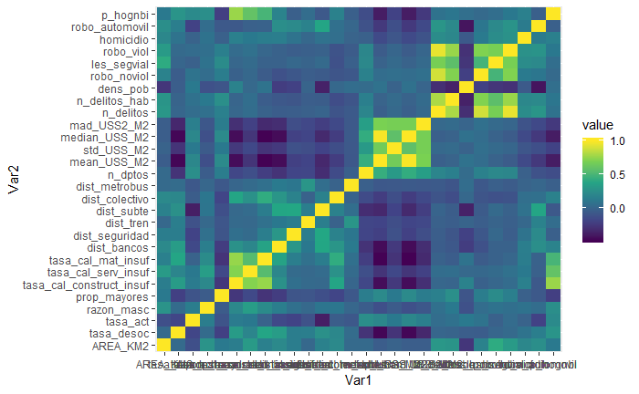

```r
select(as.data.frame(radios_delitos), -c(RADIO:HOGARES_NBI, geometry)) %>% cor(method = "pearson") %>%
    as.data.frame() %>% mutate(Var1 = factor(row.names(.), levels = row.names(.))) %>%
    gather(key = Var2, value = value, -Var1, na.rm = TRUE, factor_key = TRUE) %>%
    ggplot(aes(x = Var1, y = Var2, fill = value)) + geom_tile() + scale_fill_viridis_c()
```

Implementemos un modelo con todas las variables

```r
radios_delitos_l <- radios_delitos %>% select(n_delitos, everything(), -c(RADIO:HOGARES_NBI,
    n_delitos_hab, robo_noviol:robo_automovil)) %>% st_set_geometry(NULL)
model <- lm(n_delitos ~ ., data = radios_delitos_l)
```

```r
summary(model)
```

```
Call:
lm(formula = n_delitos ~ ., data = radios_delitos_l)

Residuals:
    Min      1Q  Median      3Q     Max
-374.73  -27.92   -8.98   11.88 1452.09

Coefficients:
                           Estimate Std. Error t value Pr(>|t|)
(Intercept)               5.607e+01  2.184e+01   2.567 0.010310 *
AREA_KM2                  1.526e+02  8.852e+00  17.242  < 2e-16 ***
tasa_desoc                2.541e+00  8.219e-01   3.091 0.002010 **
tasa_act                  1.015e+00  2.807e-01   3.616 0.000304 ***
razon_masc               -7.755e+00  3.987e+00  -1.945 0.051836 .
prop_mayores              3.798e+02  7.592e+01   5.003 5.93e-07 ***
tasa_cal_construct_insuf  1.061e+00  3.110e-01   3.410 0.000657 ***
tasa_cal_serv_insuf      -1.547e+00  4.223e-01  -3.663 0.000253 ***
tasa_cal_mat_insuf       -1.234e-01  2.551e-01  -0.484 0.628513
dist_bancos              -3.631e-02  5.420e-03  -6.699 2.43e-11 ***
dist_seguridad           -9.929e-03  3.011e-03  -3.298 0.000983 ***
dist_tren                 2.231e-03  2.266e-03   0.985 0.324836
dist_subte               -1.981e-03  1.138e-03  -1.741 0.081696 .
dist_colectivo           -1.369e-01  1.786e-02  -7.662 2.35e-14 ***
dist_metrobus            -3.305e-03  1.588e-03  -2.081 0.037479 *
n_dptos                   4.414e-01  3.975e-02  11.104  < 2e-16 ***
mean_USS_M2              -8.621e-03  1.327e-02  -0.650 0.515902
std_USS_M2                2.002e-03  6.738e-03   0.297 0.766330
median_USS_M2            -1.351e-02  1.268e-02  -1.065 0.286725
mad_USS2_M2               1.385e-02  7.751e-03   1.787 0.074053 .
dens_pob                 -1.137e-03  6.917e-05 -16.441  < 2e-16 ***
p_hognbi                  1.258e-01  2.057e-01   0.612 0.540901
---
Signif. codes:  0 ‘***’ 0.001 ‘**’ 0.01 ‘*’ 0.05 ‘.’ 0.1 ‘ ’ 1

Residual standard error: 66.79 on 3532 degrees of freedom
Multiple R-squared:  0.2544,    Adjusted R-squared:   0.25
F-statistic:  57.4 on 21 and 3532 DF,  p-value: < 2.2e-16
```

## Implementación en R `lm()`: multicolinealidad

Vamos a analizar la multicolinealidad entre los predictores. Usaremos la función `vif()` del paquete `car`

```r
library(car)
vif(model)
```

```
                AREA_KM2               tasa_desoc
                1.434081                 1.439391
                tasa_act               razon_masc
                1.426460                 1.258338
            prop_mayores tasa_cal_construct_insuf
                1.221222                 6.359161
     tasa_cal_serv_insuf       tasa_cal_mat_insuf
                2.537362                 2.957220
             dist_bancos           dist_seguridad
                1.598069                 1.266298
               dist_tren               dist_subte
                1.171414                 1.741578
          dist_colectivo            dist_metrobus
                1.399145                 1.133393
                 n_dptos              mean_USS_M2
                1.375091                68.771343
              std_USS_M2            median_USS_M2
                3.606592                58.903757
             mad_USS2_M2                 dens_pob
                2.550528                 1.417037
                p_hognbi
                3.100724
```

```r
model <- lm(n_delitos ~ . - tasa_cal_construct_insuf - tasa_cal_serv_insuf -
    tasa_cal_mat_insuf, data = radios_delitos_l)
summary(model)
```

```
Call:
lm(formula = n_delitos ~ . - tasa_cal_construct_insuf - tasa_cal_serv_insuf -
    tasa_cal_mat_insuf, data = radios_delitos_l)

Residuals:
    Min      1Q  Median      3Q     Max
-393.46  -28.45   -9.31   11.56 1448.30

Coefficients:
                 Estimate Std. Error t value Pr(>|t|)
(Intercept)     5.558e+01  2.184e+01   2.545 0.010985 *
AREA_KM2        1.458e+02  8.555e+00  17.040  < 2e-16 ***
tasa_desoc      2.675e+00  8.144e-01   3.284 0.001032 **
tasa_act        1.029e+00  2.811e-01   3.661 0.000255 ***
razon_masc     -1.059e+01  3.889e+00  -2.724 0.006477 **
prop_mayores    3.860e+02  7.578e+01   5.093 3.71e-07 ***
dist_bancos    -3.539e-02  5.395e-03  -6.560 6.17e-11 ***
dist_seguridad -9.158e-03  3.010e-03  -3.042 0.002366 **
dist_tren       1.943e-03  2.265e-03   0.857 0.391248
dist_subte     -1.939e-03  1.138e-03  -1.703 0.088569 .
dist_colectivo -1.216e-01  1.670e-02  -7.280 4.09e-13 ***
dist_metrobus  -3.606e-03  1.587e-03  -2.272 0.023119 *
n_dptos         4.555e-01  3.970e-02  11.474  < 2e-16 ***
mean_USS_M2    -1.021e-02  1.329e-02  -0.769 0.442208
std_USS_M2      2.695e-03  6.750e-03   0.399 0.689777
median_USS_M2  -1.396e-02  1.270e-02  -1.099 0.271647
mad_USS2_M2     1.516e-02  7.761e-03   1.954 0.050820 .
dens_pob       -1.076e-03  6.637e-05 -16.212  < 2e-16 ***
p_hognbi        4.039e-01  1.447e-01   2.791 0.005279 **
---
Signif. codes:  0 ‘***’ 0.001 ‘**’ 0.01 ‘*’ 0.05 ‘.’ 0.1 ‘ ’ 1

Residual standard error: 66.93 on 3535 degrees of freedom
Multiple R-squared:  0.2506,    Adjusted R-squared:  0.2468
F-statistic: 65.67 on 18 and 3535 DF,  p-value: < 2.2e-16
```

## Implementación en R `lm()`: interacciones

Supongamos que quisiéramos agregar alguna interacción podemos hacerlo con la siguiente sintaxis `p_hogaresnbi*dist_seg` que agrega tanto los términos de interacción como los efectos de cada variable por separado.

```r
model <- lm(n_delitos ~ AREA_KM2 * dist_seguridad, data = radios_delitos_l)
summary(model)
```

```
Call:
lm(formula = n_delitos ~ AREA_KM2 * dist_seguridad, data = radios_delitos_l)

Residuals:
    Min      1Q  Median      3Q     Max
-658.96  -30.18  -13.53    9.50 1478.08

Coefficients:
                          Estimate Std. Error t value Pr(>|t|)
(Intercept)              61.985148   2.611499  23.735  < 2e-16 ***
AREA_KM2                287.861129  19.936204  14.439  < 2e-16 ***
dist_seguridad           -0.009251   0.003068  -3.016  0.00258 **
AREA_KM2:dist_seguridad  -0.102660   0.014590  -7.036 2.36e-12 ***
---
Signif. codes:  0 ‘***’ 0.001 ‘**’ 0.01 ‘*’ 0.05 ‘.’ 0.1 ‘ ’ 1

Residual standard error: 72.77 on 3550 degrees of freedom
Multiple R-squared:  0.1105,    Adjusted R-squared:  0.1098
F-statistic:   147 on 3 and 3550 DF,  p-value: < 2.2e-16
```